# Homework 1

Samiha Reza

2024-09-15

# Problem 1

Here is the code chunk for *data description*.

```r
data("penguins", package = "palmerpenguins")

summary(penguins)
```

```
##       species          island    bill_length_mm  bill_depth_mm
##  Adelie   :152   Biscoe   :168   Min.   :32.10   Min.   :13.10
##  Chinstrap: 68   Dream    :124   1st Qu.:39.23   1st Qu.:15.60
##  Gentoo   :124   Torgersen: 52   Median :44.45   Median :17.30
##                                  Mean   :43.92   Mean   :17.15
##                                  3rd Qu.:48.50   3rd Qu.:18.70
##                                  Max.   :59.60   Max.   :21.50
##                                  NA's   :2       NA's   :2
##  flipper_length_mm  body_mass_g       sex           year
##  Min.   :172.0     Min.   :2700   female:165   Min.   :2007
##  1st Qu.:190.0     1st Qu.:3550   male  :168   1st Qu.:2007
##  Median :197.0     Median :4050   NA's  : 11   Median :2008
##  Mean   :200.9     Mean   :4202                Mean   :2008
##  3rd Qu.:213.0     3rd Qu.:4750                3rd Qu.:2009
##  Max.   :231.0     Max.   :6300                Max.   :2009
##  NA's   :2         NA's   :2
```

```r
nrow(penguins)
```

```
## [1] 344
```

```r
ncol(penguins)
```

```
## [1] 8
```

The “penguins” data includes 8 variables: species, island, bill length (mm), bill depth (mm), flipper length (mm), body mass (g), sex, and year. There are three species: Adelie (152 penguins), Chinstrap (68 penguins), and Gentoo (124 penguins). There are three islands: Biscoe (168 pengiuins), Dream (124 penguins), and Torgersen (52 penguins). There are 8 columns, and 344 rows, so 344 data samples.The mean flipper length in mm is 200.9.

Here is the code chunk for the *scatterplot*

```r
library(tidyverse)
```

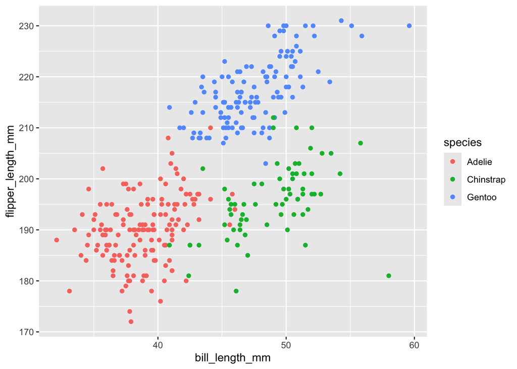

```r
ggplot(penguins, aes(x = bill_length_mm, y = flipper_length_mm, color = species)) + geom_point()
```

```r
ggsave("penguins_scatter.pdf")
```

# Problem 2

Since we have already loaded tidyverse, we do not need to do it again. Here we have a code chunk to create the *data frame*.

```r
question_2_df = tibble(
  random_sample = rnorm(10),
  logic_vector = random_sample > 0,
  character_vector = rep("character", 10),
  factor_vector = factor(rep(c("Level1", "Level2", "Level3"), length.out =10)),
)

print(question_2_df)
```

```
## # A tibble: 10 × 4
##    random_sample logic_vector character_vector factor_vector
##            <dbl> <lgl>        <chr>            <fct>
##  1        0.0191 TRUE         character        Level1
##  2       -0.377  FALSE        character        Level2
##  3       -0.188  FALSE        character        Level3
##  4        0.0235 TRUE         character        Level1
##  5       -0.183  FALSE        character        Level2
##  6        0.104  TRUE         character        Level3
##  7       -1.44   FALSE        character        Level1
##  8        0.769  TRUE         character        Level2
##  9       -0.917  FALSE        character        Level3
## 10        0.923  TRUE         character        Level1
```

Here we pull variables from the dataframe and try to find the means of each.

```r
random_sample <- question_2_df$random_sample
logic_vector <- question_2_df$logic_vector
character_vector <- question_2_df$character_vector
factor_vector <- question_2_df$factor_vector

mean(random_sample)
```

```
## [1] -0.1267162
```

```r
mean(logic_vector)
```

```
## [1] 0.5
```

```r
mean(character_vector)
```

```
## [1] NA
```

```r
mean(factor_vector)
```

```
## [1] NA
```

Only random_sample and logic_vector has a mean value. Character and Factor vector do not because “argument is not numeric or logical.”

We now check if we can convert the variables to numeric ones.

```r
numeric_logical = as.numeric(logic_vector)
# numeric_character = as.numeric(character_vector)
# numeric_factor = as.numeric(factor)
```

Character and factor vector cannot be converted to numeric, which is why it isn’t possible to find the mean.